# Class 13

Tobias Gerstenberg

February 10th, 2021

# 13 Linear model 4

## 13.1 Load packages and set plotting theme

```r
library("knitr")      # for knitting RMarkdown
library("kableExtra") # for making nice tables
library("janitor")    # for cleaning column names
library("broom")      # for tidying up linear models
library("afex")       # for running ANOVAs
library("emmeans")    # for calculating contrasts
library("car")        # for calculating ANOVAs
library("tidyverse")  # for wrangling, plotting, etc.
```

```r
theme_set(
  theme_classic() + #set the theme
    theme(text = element_text(size = 20)) #set the default text size
)

# these options here change the formatting of how comments are rendered
opts_chunk$set(comment = "",
               fig.show = "hold")

# include references for used packages
write_bib(.packages(), "packages.bib")
```

## 13.2 Load data sets

Read in the data:

```r
df.poker = read_csv("data/poker.csv") %>%
  mutate(skill = factor(skill,
                        levels = 1:2,
                        labels = c("expert", "average")),
         skill = fct_relevel(skill, "average", "expert"),
         hand = factor(hand,
                       levels = 1:3,
                       labels = c("bad", "neutral", "good")),
         limit = factor(limit,
                        levels = 1:2,
                        labels = c("fixed", "none")),
         participant = 1:n()) %>%
  select(participant, everything())
```

## 13.3 Linear contrasts

Here is a linear contrast that assumes that there is a linear relationship between the quality of one’s hand, and the final balance.

```r
df.poker = df.poker %>%
  mutate(hand_contrast = factor(hand,
                                levels = c("bad", "neutral", "good"),
                                labels = c(-1, 0, 1)),
         hand_contrast = hand_contrast %>% as.character() %>% as.numeric())

fit.contrast = lm(formula = balance ~ hand_contrast,
                  data = df.poker)
```

Here is a visualization of the model prediction together with the residuals.

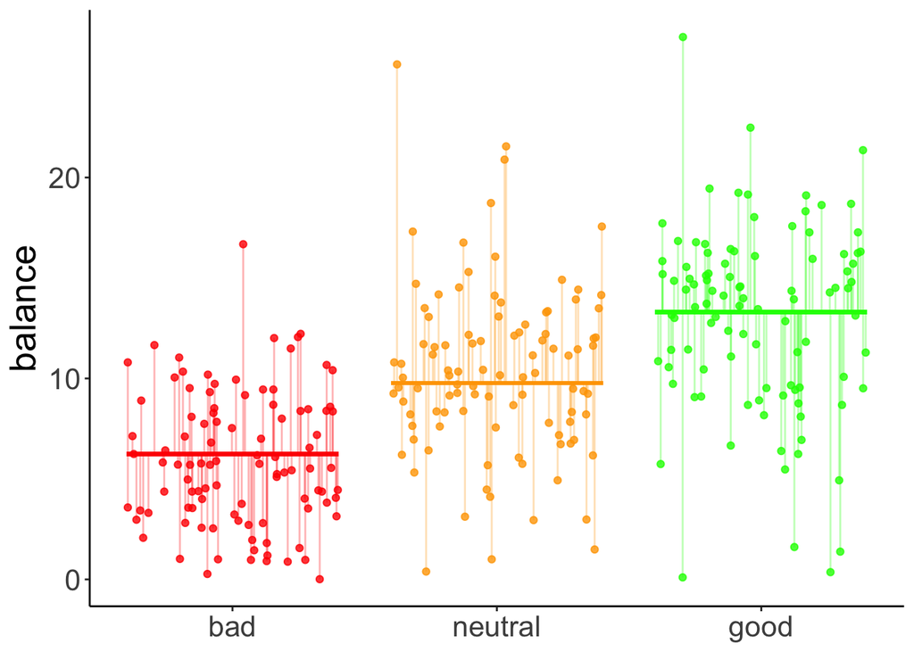

```r
df.plot = df.poker %>%
  mutate(hand_jitter = hand %>% as.numeric(),
         hand_jitter = hand_jitter + runif(n(), min = -0.4, max = 0.4))

df.tidy = fit.contrast %>%
  tidy() %>%
  select_if(is.numeric) %>%
  mutate_all(~ round(., 2))

df.augment = fit.contrast %>%
  augment() %>%
  clean_names() %>%
  bind_cols(df.plot %>% select(hand_jitter))

ggplot(data = df.plot,
       mapping = aes(x = hand_jitter,
                       y = balance,
                       color = as.factor(hand_contrast))) +
  geom_point(alpha = 0.8) +
  geom_segment(data = NULL,
               aes(x = 0.6,
                   xend = 1.4,
                   y = df.tidy$estimate[1]-df.tidy$estimate[2],
                   yend = df.tidy$estimate[1]-df.tidy$estimate[2]),
               color = "red",
               size = 1) +
  geom_segment(data = NULL,
               aes(x = 1.6,
                   xend = 2.4,
                   y = df.tidy$estimate[1],
                   yend = df.tidy$estimate[1]),
               color = "orange",
               size = 1) +
  geom_segment(data = NULL,
               aes(x = 2.6,
                   xend = 3.4,
                   y = df.tidy$estimate[1] + df.tidy$estimate[2],
                   yend = df.tidy$estimate[1] + df.tidy$estimate[2]),
               color = "green",
               size = 1) +
  geom_segment(data = df.augment,
               aes(xend = hand_jitter,
                   y = balance,
                   yend = fitted),
               alpha = 0.3) +
  labs(y = "balance") +
  scale_color_manual(values = c("red", "orange", "green")) +
  scale_x_continuous(breaks = 1:3, labels = c("bad", "neutral", "good")) +
  theme(legend.position = "none",
        axis.title.x = element_blank())
```

### 13.3.1 Hypothetical data

Here is some code to generate a hypothetical developmental data set.

```r
# make example reproducible
set.seed(1)

# means = c(5, 10, 5)
means = c(3, 5, 20)
# means = c(3, 5, 7)
# means = c(3, 7, 12)
sd = 2
sample_size = 20

# generate data
df.development = tibble(
  group = rep(c("3-4", "5-6", "7-8"), each = sample_size),
  performance = NA) %>%
  mutate(performance = ifelse(group == "3-4",
                              rnorm(sample_size,
                                    mean = means[1],
                                    sd = sd),
                              performance),
         performance = ifelse(group == "5-6",
                              rnorm(sample_size,
                                    mean = means[2],
                                    sd = sd),
                              performance),
         performance = ifelse(group == "7-8",
                              rnorm(sample_size,
                                    mean = means[3],
                                    sd = sd),
                              performance),
         group = factor(group, levels = c("3-4", "5-6", "7-8")),
         group_contrast = group %>%
           fct_recode(`-1` = "3-4",
                      `0` = "5-6",
                      `1` = "7-8") %>%
           as.character() %>%
           as.numeric())
```

Let’s define a linear contrast using the `emmeans` package, and test whether it’s significant.

```r
fit = lm(formula = performance ~ group,
         data = df.development)

fit %>%
  emmeans("group",
          contr = list(linear = c(-0.5, 0, 0.5)),
          adjust = "bonferroni") %>%
  pluck("contrasts")
```

```
 contrast estimate    SE df t.ratio p.value
 linear       8.45 0.274 57 30.856  <.0001
```

### 13.3.2 Visualization

Total variance:

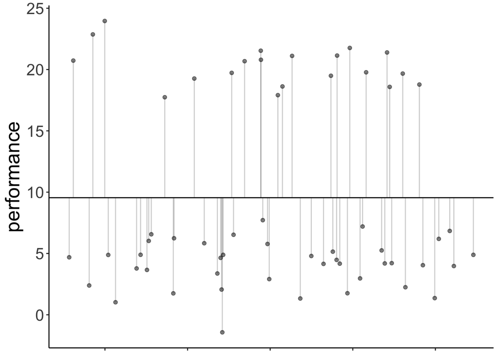

```r
set.seed(1)

fit_c = lm(formula = performance ~ 1,
           data = df.development)

df.plot = df.development %>%
  mutate(group_jitter = 1 + runif(n(), min = -0.25, max = 0.25))

df.augment = fit_c %>%
  augment() %>%
  clean_names() %>%
  bind_cols(df.plot %>% select(group, group_jitter))

ggplot(data = df.plot,
       mapping = aes(x = group_jitter,
                       y = performance,
                       fill = group)) +
  geom_hline(yintercept = mean(df.development$performance)) +
  geom_point(alpha = 0.5) +
  geom_segment(data = df.augment,
               aes(xend = group_jitter,
                   yend = fitted),
               alpha = 0.2) +
  labs(y = "performance") +
  theme(legend.position = "none",
        axis.text.x = element_blank(),
        axis.title.x = element_blank())
```

With contrast

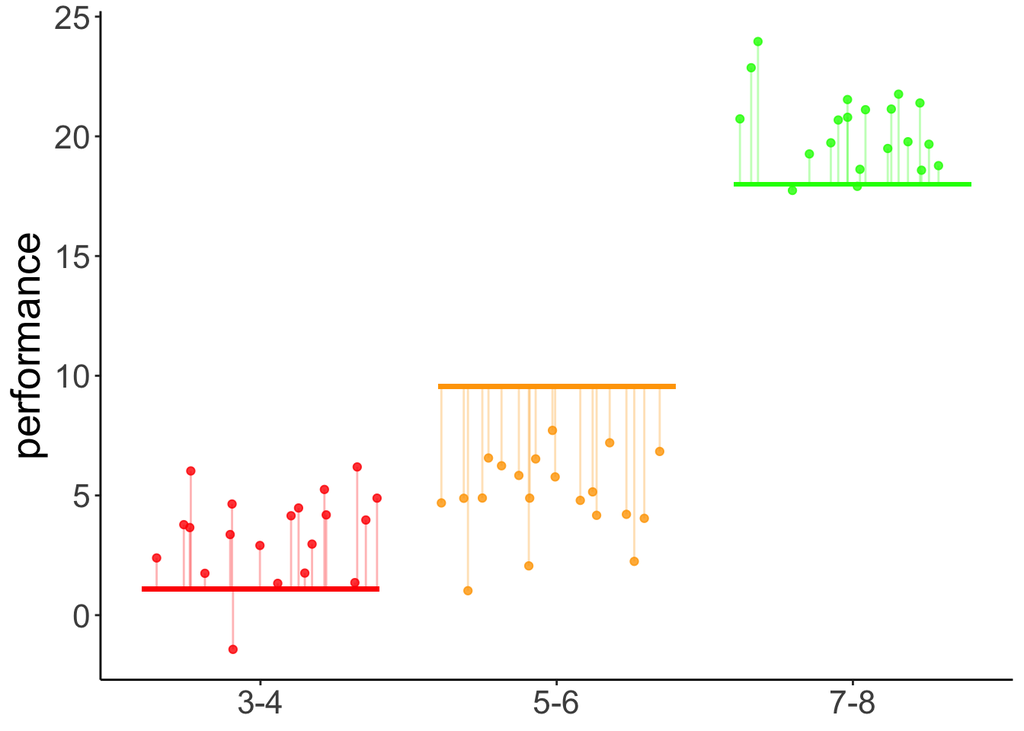

Figure 13.1: Predictions of the linear contrast model

```r
# make example reproducible
set.seed(1)

fit = lm(formula = performance ~ group_contrast,
         data = df.development)

df.plot = df.development %>%
  mutate(group_jitter = group %>% as.numeric(),
         group_jitter = group_jitter + runif(n(), min = -0.4, max = 0.4))

df.tidy = fit %>%
  tidy() %>%
  select(where(is.numeric)) %>%
  mutate(across(.fns = ~ round(. , 2)))

df.augment = fit %>%
  augment() %>%
  clean_names() %>%
  bind_cols(df.plot %>% select(group_jitter))

ggplot(data = df.plot,
       mapping = aes(x = group_jitter,
                       y = performance,
                       color = as.factor(group_contrast))) +
  geom_point(alpha = 0.8) +
  geom_segment(data = NULL,
               aes(x = 0.6,
                   xend = 1.4,
                   y = df.tidy$estimate[1]-df.tidy$estimate[2],
                   yend = df.tidy$estimate[1]-df.tidy$estimate[2]),
               color = "red",
               size = 1) +
  geom_segment(data = NULL,
               aes(x = 1.6,
                   xend = 2.4,
                   y = df.tidy$estimate[1],
                   yend = df.tidy$estimate[1]),
               color = "orange",
               size = 1) +
  geom_segment(data = NULL,
               aes(x = 2.6,
                   xend = 3.4,
                   y = df.tidy$estimate[1] + df.tidy$estimate[2],
                   yend = df.tidy$estimate[1] + df.tidy$estimate[2]),
               color = "green",
               size = 1) +
  geom_segment(data = df.augment,
               aes(xend = group_jitter,
                   y = performance,
                   yend = fitted),
               alpha = 0.3) +
  labs(y = "performance") +
  scale_color_manual(values = c("red", "orange", "green")) +
  scale_x_continuous(breaks = 1:3, labels = levels(df.development$group)) +
  theme(legend.position = "none",
        axis.title.x = element_blank())
```

Results figure

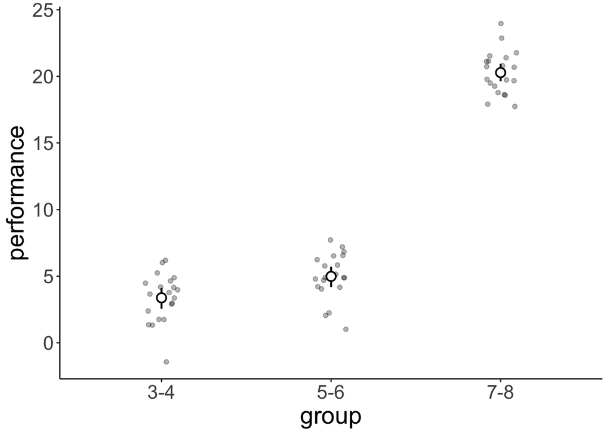

```r
df.development %>%
  ggplot(aes(x = group, y = performance)) +
  geom_point(alpha = 0.3, position = position_jitter(width = 0.1, height = 0)) +
  stat_summary(fun.data = "mean_cl_boot",
               shape = 21,
               fill = "white",
               size = 0.75)
```

Here we test some more specific hypotheses: the the two youngest groups of children are different from the oldest group, and that the 3 year olds are different from the 5 year olds.

```r
#  fit the linear model
fit = lm(formula = performance ~ group,
         data = df.development)

# check factor levels
levels(df.development$group)
```

```
[1] "3-4" "5-6" "7-8"
```

```r
# define the contrasts of interest
contrasts = list(young_vs_old = c(-0.5, -0.5, 1),
                 three_vs_five = c(-0.5, 0.5, 0))

# compute significance test on contrasts
fit %>%
  emmeans("group",
          contr = contrasts,
          adjust = "bonferroni") %>%
  pluck("contrasts")
```

```
 contrast      estimate    SE df t.ratio p.value
 young_vs_old    16.094 0.474 57 33.936  <.0001
 three_vs_five    0.803 0.274 57  2.933  0.0097

P value adjustment: bonferroni method for 2 tests
```

### 13.3.3 Post-hoc tests

Post-hoc tests for a single predictor (using the poker data set).

```r
fit = lm(formula = balance ~ hand,
         data = df.poker)

# post hoc tests
fit %>%
  emmeans(pairwise ~ hand,
          adjust = "bonferroni") %>%
  pluck("contrasts")
```

```
 contrast       estimate    SE  df t.ratio p.value
 bad - neutral     -4.41 0.581 297  -7.576 <.0001
 bad - good        -7.08 0.581 297 -12.185 <.0001
 neutral - good    -2.68 0.581 297  -4.609 <.0001

P value adjustment: bonferroni method for 3 tests
```

Post-hoc tests for two predictors (:

```r
# fit the model
fit = lm(formula = balance ~ hand + skill,
         data = df.poker)

# post hoc tests
fit %>%
  emmeans(pairwise ~ hand + skill,
          adjust = "bonferroni") %>%
  pluck("contrasts")
```

```
 contrast                         estimate    SE  df t.ratio p.value
 bad average - neutral average      -4.405 0.580 296  -7.593 <.0001
 bad average - good average         -7.085 0.580 296 -12.212 <.0001
 bad average - bad expert           -0.724 0.474 296  -1.529 1.0000
 bad average - neutral expert       -5.129 0.749 296  -6.849 <.0001
 bad average - good expert          -7.809 0.749 296 -10.427 <.0001
 neutral average - good average     -2.680 0.580 296  -4.619 0.0001
 neutral average - bad expert        3.681 0.749 296   4.914 <.0001
 neutral average - neutral expert   -0.724 0.474 296  -1.529 1.0000
 neutral average - good expert      -3.404 0.749 296  -4.545 0.0001
 good average - bad expert           6.361 0.749 296   8.492 <.0001
 good average - neutral expert       1.955 0.749 296   2.611 0.1424
 good average - good expert         -0.724 0.474 296  -1.529 1.0000
 bad expert - neutral expert        -4.405 0.580 296  -7.593 <.0001
 bad expert - good expert           -7.085 0.580 296 -12.212 <.0001
 neutral expert - good expert       -2.680 0.580 296  -4.619 0.0001

P value adjustment: bonferroni method for 15 tests
```

```r
fit = lm(formula = balance ~ hand,
         data = df.poker)

# comparing each to the mean
fit %>%
  emmeans(eff ~ hand) %>%
  pluck("contrasts")
```

```
 contrast       estimate    SE  df t.ratio p.value
 bad effect       -3.830 0.336 297 -11.409 <.0001
 neutral effect    0.575 0.336 297   1.713 0.0877
 good effect       3.255 0.336 297   9.696 <.0001

P value adjustment: fdr method for 3 tests
```

```r
# one vs. all others
fit %>%
  emmeans(del.eff ~ hand) %>%
  pluck("contrasts")
```

```
 contrast       estimate    SE  df t.ratio p.value
 bad effect       -5.745 0.504 297 -11.409 <.0001
 neutral effect    0.863 0.504 297   1.713 0.0877
 good effect       4.882 0.504 297   9.696 <.0001

P value adjustment: fdr method for 3 tests
```

### 13.3.4 Understanding dummy coding

```r
fit = lm(formula = balance ~ 1 + hand,
         data = df.poker)

fit %>%
  summary()
```

```
Call:
lm(formula = balance ~ 1 + hand, data = df.poker)

Residuals:
     Min       1Q   Median       3Q      Max
-12.9264  -2.5902  -0.0115   2.6573  15.2834

Coefficients:
            Estimate Std. Error t value Pr(>|t|)
(Intercept)   5.9415     0.4111  14.451  < 2e-16 ***
handneutral   4.4051     0.5815   7.576 4.55e-13 ***
handgood      7.0849     0.5815  12.185  < 2e-16 ***
---
Signif. codes:  0 '***' 0.001 '**' 0.01 '*' 0.05 '.' 0.1 ' ' 1

Residual standard error: 4.111 on 297 degrees of freedom
Multiple R-squared:  0.3377,    Adjusted R-squared:  0.3332
F-statistic:  75.7 on 2 and 297 DF,  p-value: < 2.2e-16
```

```r
model.matrix(fit) %>%
  as_tibble() %>%
  distinct()
```

```
# A tibble: 3 x 3
  `(Intercept)` handneutral handgood
          <dbl>       <dbl>    <dbl>
1             1           0        0
2             1           1        0
3             1           0        1
```

```r
df.poker %>%
  select(participant, hand, balance) %>%
  group_by(hand) %>%
  top_n(3, wt = -participant) %>%
  kable(digits = 2) %>%
  kable_styling(bootstrap_options = "striped",
                full_width = F)
```

| participant | hand | balance |
| --- | --- | --- |
| 1 | bad | 4.00 |
| 2 | bad | 5.55 |
| 3 | bad | 9.45 |
| 51 | neutral | 11.74 |
| 52 | neutral | 10.04 |
| 53 | neutral | 9.49 |
| 101 | good | 10.86 |
| 102 | good | 8.68 |
| 103 | good | 14.36 |

### 13.3.5 Understanding effect coding

```r
fit = lm(formula = balance ~ 1 + hand,
         contrasts = list(hand = "contr.sum"),
         data = df.poker)

fit %>%
  summary()
```

```
Call:
lm(formula = balance ~ 1 + hand, data = df.poker, contrasts = list(hand = "contr.sum"))

Residuals:
     Min       1Q   Median       3Q      Max
-12.9264  -2.5902  -0.0115   2.6573  15.2834

Coefficients:
            Estimate Std. Error t value Pr(>|t|)
(Intercept)   9.7715     0.2374  41.165   <2e-16 ***
hand1        -3.8300     0.3357 -11.409   <2e-16 ***
hand2         0.5751     0.3357   1.713   0.0877 .
---
Signif. codes:  0 '***' 0.001 '**' 0.01 '*' 0.05 '.' 0.1 ' ' 1

Residual standard error: 4.111 on 297 degrees of freedom
Multiple R-squared:  0.3377,    Adjusted R-squared:  0.3332
F-statistic:  75.7 on 2 and 297 DF,  p-value: < 2.2e-16
```

```r
model.matrix(fit) %>%
  as_tibble() %>%
  distinct() %>%
  kable(digits = 2) %>%
  kable_styling(bootstrap_options = "striped",
                full_width = F)
```

| (Intercept) | hand1 | hand2 |
| --- | --- | --- |
| 1 | 1 | 0 |
| 1 | 0 | 1 |
| 1 | -1 | -1 |

## References

Bates, Douglas, and Martin Maechler. 2021. *Matrix: Sparse and Dense Matrix Classes and Methods*. http://Matrix.R-forge.R-project.org/.

Bates, Douglas, Martin Maechler, Ben Bolker, and Steven Walker. 2020. *Lme4: Linear Mixed-Effects Models Using Eigen and S4*. https://github.com/lme4/lme4/.

Bates, Douglas, Martin Mächler, Ben Bolker, and Steve Walker. 2015. “Fitting Linear Mixed-Effects Models Using lme4.” *Journal of Statistical Software* 67 (1): 1–48. https://doi.org/10.18637/jss.v067.i01.

Firke, Sam. 2021. *Janitor: Simple Tools for Examining and Cleaning Dirty Data*. https://github.com/sfirke/janitor.

Fox, John, and Sanford Weisberg. 2019. *An R Companion to Applied Regression*. Third. Thousand Oaks CA: Sage. https://socialsciences.mcmaster.ca/jfox/Books/Companion/.

Fox, John, Sanford Weisberg, and Brad Price. 2020a. *Car: Companion to Applied Regression*. https://CRAN.R-project.org/package=car.

———. 2020b. *carData: Companion to Applied Regression Data Sets*. https://CRAN.R-project.org/package=carData.

Henry, Lionel, and Hadley Wickham. 2020. *Purrr: Functional Programming Tools*. https://CRAN.R-project.org/package=purrr.

Lenth, Russell V. 2020. *Emmeans: Estimated Marginal Means, Aka Least-Squares Means*. https://github.com/rvlenth/emmeans.

Müller, Kirill, and Hadley Wickham. 2021. *Tibble: Simple Data Frames*. https://CRAN.R-project.org/package=tibble.

R Core Team. 2020. *R: A Language and Environment for Statistical Computing*. Vienna, Austria: R Foundation for Statistical Computing. https://www.R-project.org/.

Robinson, David, Alex Hayes, and Simon Couch. 2020. *Broom: Convert Statistical Objects into Tidy Tibbles*. https://CRAN.R-project.org/package=broom.

Singmann, Henrik, Ben Bolker, Jake Westfall, Frederik Aust, and Mattan S. Ben-Shachar. 2021. *Afex: Analysis of Factorial Experiments*. https://CRAN.R-project.org/package=afex.

Wickham, Hadley. 2016. *Ggplot2: Elegant Graphics for Data Analysis*. Springer-Verlag New York. https://ggplot2.tidyverse.org.

———. 2019a. *Stringr: Simple, Consistent Wrappers for Common String Operations*. https://CRAN.R-project.org/package=stringr.

———. 2019b. *Tidyverse: Easily Install and Load the Tidyverse*. https://CRAN.R-project.org/package=tidyverse.

———. 2020. *Tidyr: Tidy Messy Data*. https://CRAN.R-project.org/package=tidyr.

———. 2021. *Forcats: Tools for Working with Categorical Variables (Factors)*. https://CRAN.R-project.org/package=forcats.

Wickham, Hadley, Mara Averick, Jennifer Bryan, Winston Chang, Lucy D’Agostino McGowan, Romain François, Garrett Grolemund, et al. 2019. “Welcome to the tidyverse.” *Journal of Open Source Software* 4 (43): 1686. https://doi.org/10.21105/joss.01686.

Wickham, Hadley, Winston Chang, Lionel Henry, Thomas Lin Pedersen, Kohske Takahashi, Claus Wilke, Kara Woo, Hiroaki Yutani, and Dewey Dunnington. 2020. *Ggplot2: Create Elegant Data Visualisations Using the Grammar of Graphics*. https://CRAN.R-project.org/package=ggplot2.

Wickham, Hadley, Romain François, Lionel Henry, and Kirill Müller. 2021. *Dplyr: A Grammar of Data Manipulation*. https://CRAN.R-project.org/package=dplyr.

Wickham, Hadley, and Jim Hester. 2020. *Readr: Read Rectangular Text Data*. https://CRAN.R-project.org/package=readr.

Xie, Yihui. 2014. “Knitr: A Comprehensive Tool for Reproducible Research in R.” In *Implementing Reproducible Computational Research*, edited by Victoria Stodden, Friedrich Leisch, and Roger D. Peng. Chapman; Hall/CRC. http://www.crcpress.com/product/isbn/9781466561595.

———. 2015. *Dynamic Documents with R and Knitr*. 2nd ed. Boca Raton, Florida: Chapman; Hall/CRC. https://yihui.org/knitr/.

———. 2021. *Knitr: A General-Purpose Package for Dynamic Report Generation in r*. https://yihui.org/knitr/.

Zhu, Hao. 2020. *kableExtra: Construct Complex Table with Kable and Pipe Syntax*. https://CRAN.R-project.org/package=kableExtra.